# Customer Behavioural Analytics in the Retail Sector

#### **Team CuBA**

1. Nadiia Honcharenko (220681, nadiia.honcharenko@st.ovgu.de)
2. Rutuja Shivraj Pawar (220051, rutuja.pawar@ovgu.de)
3. Shivani Jadhav (223856, shivani.jadhav@st.ovgu.de)
4. Sumit Kundu (217453, sumit.kundu@st.ovgu.de)

#### **Under the Guidance of**

M.Sc. Uli Niemann

#### **1. Overview and Motivation**

A customer is a key-centric factor for any business to be successful. Conventional wisdom tells us that the cost of retaining an existing customer is far less than acquiring a new one. In order that a business has a sustainable growth, the retention of its old customer base and expansion of the new customer base is very critical. This demands from a business to understand the behaviour of its customers in relation to the business. Therefore obtaining a 360° view of its customers is crucial for a business looking for a competitive edge in the market. In such a scenario, Customer Behavioural Analytics plays an important role in leveraging data analytics to find meaningful behavioural patterns in the customer-specific business data.  
Consequently, this project aims to understand the consumer behaviour in the retail sector. Decoding the consumer behaviour will be based on understanding how consumers make purchase decisions and what factors influence those decisions. This project also aims to discover existence of dependencies between customers, products and shops to highlight further insights about their behaviour. These meaningful insights will further help a business to implement stratergies leading to an increased revenue through customer satisfaction.

#### **2. Project Objective**

This project aims to address the problem of understanding behaviour of customers of an Italian retail distribution company *Coop* in a single Italian city. The project intends to discover different analytical insights about the purchase behaviour of the customers through answering different formulated Research Questions (RQ)

#### **3. Data Source**

Supermarket aggr.Customer[^1]  
The dataset to be used is the retail market data of one of the largest Italian retail distribution company called *Coop* for a single Italian city.  
The Supermarket aggr.Customer dataset used for the analysis contains data aggregated from customer and information from shops[^2] (Pennacchioli et al. 2013) and pivoted to new columns. The dataset thus contains 40 features with 60,366 instances and is approximately 14.0 MB in size.

#### **4. Related Work and its Comparision to the Project**

The paper (Pennacchioli et al. 2013) studies and highlights the product range effect illustrating that the customers are focussed more on the needs satisfied by the product. If the satisfaction is more, customers are ready to travel long distances to purchase them and even pay more. The study is based on the creation of a data mining framework and introduction of a new measurement called as product sophistication to study the range effect. The paper also studies the effect of the introduced measure on the accuracy of predicting the shop selected by the customer to buy a particular product. Hence this paper studies the customer behaviour in the retail sector majorly based on this range effect.  
However, on the contrary, our analysis is not carried out on the same datasets as used in the paper but our dataset contains data aggregated from customer and information from shops and pivoted to new columns. As we have new columns in our dataset, the perspective of our analysis becomes different. Based on our data and understanding its different features, we framed different Research Questions to be answered from the data. These research questions do not focus only on one aspect (as the range effect in the paper), but attempt to decode the customer behaviour in different ways. Unlike the methodology used in the paper, this project obtains customer behavioural insights through the application of machine learning algorithms on the data. Through this, the project thus studies the consumer nature to determine whether customers are ready to travel long distances in spite of the high average price in a shop and what are the factors that contribute to their long distance travel. Additionally, likelihood of a customer to select a particular shop, different customer segments and discovering top 100 profitable customers is also studied in the scope of the project.

#### **5. Initial Questions**

Below are the RQs which were formulated at the initial stages of the project based on a primary understanding of the data but without a detailed Exploratory Data Analysis,

**1. Are customers willing to travel long distances to purchase products in spite of the high average product price in a shop?**  
*Relevance:* This will help to understand whether the price is an important factor affecting the majority of customers purchase decisions.

**2. Which are the products for which customers are ready to travel long distances and for which products they select the closest shop?**  
*Relevance:* This will help to understand the nature of the products in the context of proximity. It is assumed that customers will select closest shops to buy daily products like grocery but may travel long distances to buy one-time-purchase products like kitchen equipment. As Data Science is results-driven and not based solely on intuition, this question can help to verify this assumption.

**3. What is the maximum likelihood of a customer to select a particular shop to purchase a particular product?**  
*Relevance:* This will help to understand that which shops in the retail chain are in demand for a particular product. This can further facilitate better stock management to meet customer demands.

**4. What is the ranking of the shops in terms of attracting more customers and thus generating more revenue and what is their individual customer base?**  
*Relevance:* This will help to understand the most popular shops in the retail chain and target different shop-level marketing schemes to the appropriate customers through customer segmentation.

**5. Which are the customers that are most profitable in terms of revenue generation?**  
*Relevance:* This will help to understand the customers with potential high Customer Lifetime Value and target appropriate loyalty programs to generate satisfied loyal customers as advocates for the business.

#### **6. Data Wrangling**

Data Wrangling consists of different steps transforming data from raw form into a clean form which is appropriate and accurate for data analysis. Below are the different steps which were carried out as a part of Data Wrangling,

**1) Examination of the input dataset structure**

**Visualize the input dataset**

```r
library(tidyverse)
library(DataExplorer)

# Read data from the input csv file
file_path<- "Input Dataset/Supermarket aggr.Customer.csv"
supermarket_data <- read_csv(file_path)

# Converts data to tbl class. as tbl’s are easier to examine than data frames and View data set in spreadsheet-like display
supermarket_tbl<-tbl_df(supermarket_data)

# Check the dimension of the input dataset and the variables through a plot
plot_str(supermarket_tbl)
```

[output not shown]

**Generate the input dataset statistics**

```r
# Data Statistics
introduce(supermarket_tbl)
```

```
## # A tibble: 1 x 9
##    rows columns discrete_columns continuous_colu~ all_missing_col~
##   <int>   <int>            <int>            <int>            <int>
## 1 60366      40                0               40                0
## # ... with 4 more variables: total_missing_values <int>,
## #   complete_rows <int>, total_observations <int>, memory_usage <dbl>
```

**Generate the input dataset header information**

```r
# Header Info with data types
sapply(supermarket_tbl, class)
```

```
##                      customer_id            avg_distance_to_shops
##                        "integer"                        "numeric"
##            min_distance_to_shops            max_distance_to_shops
##                        "numeric"                        "numeric"
##               products_purchased        unique_products_purchased
##                        "integer"                        "integer"
##                 amount_purchased                     avg_purchase
##                        "numeric"                        "numeric"
##                        avg_price                       shops_used
##                        "numeric"                        "integer"
##                  distance_shop_1                  distance_shop_2
##                        "numeric"                        "numeric"
##                  distance_shop_3                  distance_shop_4
##                        "numeric"                        "numeric"
##                  distance_shop_5        products_purchased_shop_1
##                        "numeric"                        "integer"
##        products_purchased_shop_2        products_purchased_shop_3
##                        "integer"                        "integer"
##        products_purchased_shop_4        products_purchased_shop_5
##                        "integer"                        "integer"
## unique_products_purchased_shop_1 unique_products_purchased_shop_2
##                        "integer"                        "integer"
## unique_products_purchased_shop_3 unique_products_purchased_shop_4
##                        "integer"                        "integer"
## unique_products_purchased_shop_5          amount_purchased_shop_1
##                        "integer"                        "numeric"
##          amount_purchased_shop_2          amount_purchased_shop_3
##                        "numeric"                        "numeric"
##          amount_purchased_shop_4          amount_purchased_shop_5
##                        "numeric"                        "numeric"
##              avg_purchase_shop_1              avg_purchase_shop_2
##                        "numeric"                        "numeric"
##              avg_purchase_shop_3              avg_purchase_shop_4
##                        "numeric"                        "numeric"
##              avg_purchase_shop_5                 avg_price_shop_1
##                        "numeric"                        "numeric"
##                 avg_price_shop_2                 avg_price_shop_3
##                        "numeric"                        "numeric"
##                 avg_price_shop_4                 avg_price_shop_5
##                        "numeric"                        "numeric"
```

**Generate the input dataset summary**

```r
# Data Summary
summary(supermarket_tbl)
```

```
##   customer_id    avg_distance_to_shops min_distance_to_shops
##  Min.   :    1   Min.   :   6.642      Min.   :   6.642
##  1st Qu.:15092   1st Qu.:1250.239      1st Qu.: 573.611
##  Median :30184   Median :1936.880      Median :1184.943
##  Mean   :30184   Mean   :2030.227      Mean   :1396.438
##  3rd Qu.:45275   3rd Qu.:2569.707      3rd Qu.:1962.384
##  Max.   :60366   Max.   :9004.164      Max.   :9004.164
##                  NA's   :1             NA's   :1
##  max_distance_to_shops products_purchased unique_products_purchased
##  Min.   :   6.642      Min.   :    1      Min.   :   1.0
##  1st Qu.:2117.183      1st Qu.:  227      1st Qu.: 127.0
##  Median :2869.195      Median :  925      Median : 304.0
##  Mean   :2942.668      Mean   : 1779      Mean   : 330.7
##  3rd Qu.:3580.670      3rd Qu.: 2552      3rd Qu.: 500.0
##  Max.   :9267.698      Max.   :22131      Max.   :1465.0
##  NA's   :1             NA's   :1          NA's   :1
##  amount_purchased    avg_purchase       avg_price         shops_used
##  Min.   :    0.21   Min.   :  0.212   Min.   :  0.212   Min.   :1.00
##  1st Qu.:  653.11   1st Qu.:  4.533   1st Qu.:  2.534   1st Qu.:2.00
##  Median : 2355.14   Median :  6.863   Median :  2.944   Median :2.00
##  Mean   : 4235.49   Mean   :  8.532   Mean   :  3.667   Mean   :2.38
##  3rd Qu.: 6054.63   3rd Qu.: 10.430   3rd Qu.:  3.558   3rd Qu.:3.00
##  Max.   :51588.66   Max.   :787.569   Max.   :787.569   Max.   :5.00
##  NA's   :1          NA's   :1         NA's   :1         NA's   :1
##  distance_shop_1   distance_shop_2   distance_shop_3   distance_shop_4
##  Min.   :  93.28   Min.   :  11.19   Min.   :  17.84   Min.   :   6.642
##  1st Qu.:1609.58   1st Qu.:1501.90   1st Qu.:1253.84   1st Qu.:1532.685
##  Median :2288.68   Median :2355.40   Median :1746.17   Median :2704.323
##  Mean   :2496.63   Mean   :2488.24   Mean   :1924.97   Mean   :2882.799
##  3rd Qu.:3144.06   3rd Qu.:3370.72   3rd Qu.:2323.56   3rd Qu.:4055.997
##  Max.   :8019.92   Max.   :9004.16   Max.   :7395.25   Max.   :9273.686
##
##  distance_shop_5   products_purchased_shop_1 products_purchased_shop_2
##  Min.   :  25.46   Min.   :    0.0           Min.   :    0.0
##  1st Qu.:1173.41   1st Qu.:   49.0           1st Qu.:    0.0
##  Median :1852.93   Median :  292.0           Median :   53.0
##  Mean   :2020.90   Mean   :  887.8           Mean   :  605.4
##  3rd Qu.:2466.56   3rd Qu.: 1072.0           3rd Qu.:  471.0
##  Max.   :7465.81   Max.   :17016.0           Max.   :22110.0
##
```

[output cut: 57 more lines]

```
##  Min.   :  0.0000    Min.   :  0.000   Min.   :  0.000
##  1st Qu.:  0.0000    1st Qu.:  2.648   1st Qu.:  0.000
##  Median :  0.0000    Median :  3.252   Median :  2.297
##  Mean   :  0.8081    Mean   :  4.681   Mean   :  2.298
##  3rd Qu.:  0.0000    3rd Qu.:  4.167   3rd Qu.:  2.717
##  Max.   :133.9673    Max.   :787.569   Max.   :787.569
##
##  avg_price_shop_3   avg_price_shop_4   avg_price_shop_5
##  Min.   :  0.0000   Min.   :  0.0000   Min.   :  0.0000
##  1st Qu.:  0.0000   1st Qu.:  0.0000   1st Qu.:  0.0000
##  Median :  0.0000   Median :  0.0000   Median :  0.0000
##  Mean   :  0.7603   Mean   :  0.4445   Mean   :  0.4536
##  3rd Qu.:  1.8403   3rd Qu.:  0.0000   3rd Qu.:  0.0000
##  Max.   :263.2340   Max.   :522.6070   Max.   :133.9673
##
```

**Visualize the data types in the input dataset**

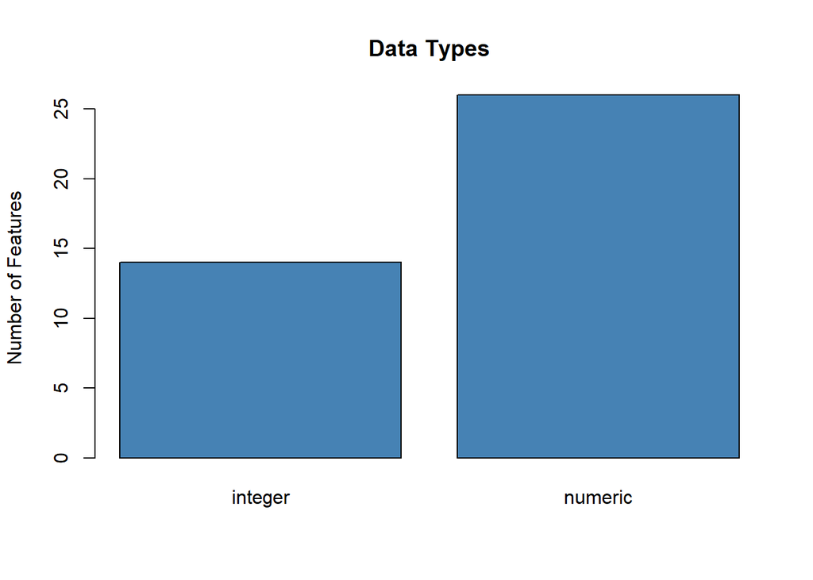

```r
# Plot the count of feature based on different data types (Majority of them are Numeric)
data_types <- function(frame) {
  res <- lapply(frame, class)
  res_frame <- data.frame(unlist(res))
  barplot(table(res_frame), main="Data Types", col="steelblue", ylab="Number of Features")
}
data_types(supermarket_tbl)
```

**2) Input dataset cleaning and processing**

**Visualize the missing values in the input dataset**

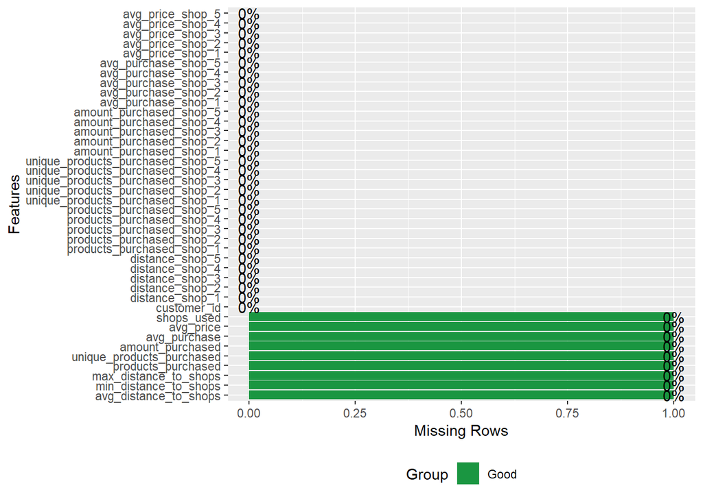

```r
# Plot missing values in the dataset
plot_missing(supermarket_tbl)
```

**Eliminate the mising values in the input dataset**

```r
# Eliminate the missing values in the dataset
supermarket_tbl_Clean1<-na.omit(supermarket_tbl)
na.action(supermarket_tbl_Clean1)
```

```
## 44617
## 44617
## attr(,"class")
## [1] "omit"
```

```r
# Percentage of data missing (Should be 0%)
missing_data_count = sum(!complete.cases(supermarket_tbl_Clean1))
total_data = dim(supermarket_tbl_Clean1)[1]
missing_data_percent = (missing_data_count/total_data) * 100
missing_data_percent
```

```
## [1] 0
```

**Eliminate the duplicate rows in the input dataset**

```r
# Eliminate duplicate rows
distinct(supermarket_tbl_Clean1)
```

```
## # A tibble: 60,365 x 40
##    customer_id avg_distance_to~ min_distance_to~ max_distance_to~
##          <int>            <dbl>            <dbl>            <dbl>
##  1           1            1435.             986.            4083.
##  2           2             910.             255.            2295.
##  3           3            1499.             754.            2832.
##  4           4             562.             363.            2210.
##  5           5             605.             275.            1375.
##  6           6            2604.            1972.            3697.
##  7           7            2069.            2069.            2069.
##  8           8            1399.             245.            1680.
##  9           9            1789.             165.            3200.
## 10          10            1940.             969.            2438.
## # ... with 60,355 more rows, and 36 more variables:
## #   products_purchased <int>, unique_products_purchased <int>,
## #   amount_purchased <dbl>, avg_purchase <dbl>, avg_price <dbl>,
## #   shops_used <int>, distance_shop_1 <dbl>, distance_shop_2 <dbl>,
## #   distance_shop_3 <dbl>, distance_shop_4 <dbl>, distance_shop_5 <dbl>,
## #   products_purchased_shop_1 <int>, products_purchased_shop_2 <int>,
## #   products_purchased_shop_3 <int>, products_purchased_shop_4 <int>,
## #   products_purchased_shop_5 <int>,
## #   unique_products_purchased_shop_1 <int>,
## #   unique_products_purchased_shop_2 <int>,
## #   unique_products_purchased_shop_3 <int>,
## #   unique_products_purchased_shop_4 <int>,
## #   unique_products_purchased_shop_5 <int>, amount_purchased_shop_1 <dbl>,
## #   amount_purchased_shop_2 <dbl>, amount_purchased_shop_3 <dbl>,
## #   amount_purchased_shop_4 <dbl>, amount_purchased_shop_5 <dbl>,
## #   avg_purchase_shop_1 <dbl>, avg_purchase_shop_2 <dbl>,
## #   avg_purchase_shop_3 <dbl>, avg_purchase_shop_4 <dbl>,
## #   avg_purchase_shop_5 <dbl>, avg_price_shop_1 <dbl>,
## #   avg_price_shop_2 <dbl>, avg_price_shop_3 <dbl>,
## #   avg_price_shop_4 <dbl>, avg_price_shop_5 <dbl>
```

**Round the decimal values in the input dataset**

```r
# Round the decimal value columns upto 4 decimal places
is.num <- sapply(supermarket_tbl_Clean1, is.numeric)
supermarket_tbl_Clean1[is.num] <- lapply(supermarket_tbl_Clean1[is.num], round, 4)
```

**Rename the column names in the input dataset**

```r
# Rename column names

## From products_purchased to products_purchased_total
names(supermarket_tbl_Clean1)[names(supermarket_tbl_Clean1) == 'products_purchased'] <- 'products_purchased_total'

## From shops_used to shops_used_total
names(supermarket_tbl_Clean1)[names(supermarket_tbl_Clean1) == 'shops_used'] <- 'shops_used_total'

## From amount_purchased to amount_purchased_total
names(supermarket_tbl_Clean1)[names(supermarket_tbl_Clean1) == 'amount_purchased'] <- 'amount_purchased_total'

## From min_distance_to_shops to min_dist_to_custSel_shops
names(supermarket_tbl_Clean1)[names(supermarket_tbl_Clean1) == 'min_distance_to_shops'] <- 'min_dist_to_custSel_shops'

## From max_distance_to_shops to max_dist_to_custSel_shops
names(supermarket_tbl_Clean1)[names(supermarket_tbl_Clean1) == 'max_distance_to_shops'] <- 'max_dist_to_custSel_shops'

## From unique_products_purchased to unique_products_purchased_total_exclCommon
names(supermarket_tbl_Clean1)[names(supermarket_tbl_Clean1) == 'unique_products_purchased'] <- 'unique_products_purchased_total_exclCommon'

## From avg_distance_to_shops to avg_distance_to_all_shops
names(supermarket_tbl_Clean1)[names(supermarket_tbl_Clean1) == 'avg_distance_to_shops'] <- 'avg_distance_to_all_shops'

## From avg_price_shop_1 to avg_product_price_shop_1
names(supermarket_tbl_Clean1)[names(supermarket_tbl_Clean1) == 'avg_price_shop_1'] <- 'avg_product_price_shop_1'

## From avg_price_shop_2 to avg_product_price_shop_2
names(supermarket_tbl_Clean1)[names(supermarket_tbl_Clean1) == 'avg_price_shop_2'] <- 'avg_product_price_shop_2'

## From avg_price_shop_3 to avg_product_price_shop_3
names(supermarket_tbl_Clean1)[names(supermarket_tbl_Clean1) == 'avg_price_shop_3'] <- 'avg_product_price_shop_3'

## From avg_price_shop_4 to avg_product_price_shop_4
names(supermarket_tbl_Clean1)[names(supermarket_tbl_Clean1) == 'avg_price_shop_4'] <- 'avg_product_price_shop_4'

## From avg_price_shop_5 to avg_product_price_shop_5
names(supermarket_tbl_Clean1)[names(supermarket_tbl_Clean1) == 'avg_price_shop_5'] <- 'avg_product_price_shop_5'

## From avg_price to avg_purchased_product_price_allShops
names(supermarket_tbl_Clean1)[names(supermarket_tbl_Clean1) == 'avg_price'] <- 'avg_purchased_product_price_allShops'

## From avg_purchase_shop_1 to avg_purchase_amount_shop_1
names(supermarket_tbl_Clean1)[names(supermarket_tbl_Clean1) == 'avg_purchase_shop_1'] <- 'avg_purchase_amount_shop_1'

## From avg_purchase_shop_2 to avg_purchase_amount_shop_1
names(supermarket_tbl_Clean1)[names(supermarket_tbl_Clean1) == 'avg_purchase_shop_2'] <- 'avg_purchase_amount_shop_2'

## From avg_purchase_shop_3 to avg_purchase_amount_shop_3
names(supermarket_tbl_Clean1)[names(supermarket_tbl_Clean1) == 'avg_purchase_shop_3'] <- 'avg_purchase_amount_shop_3'

## From avg_purchase_shop_4 to avg_purchase_amount_shop_4
names(supermarket_tbl_Clean1)[names(supermarket_tbl_Clean1) == 'avg_purchase_shop_4'] <- 'avg_purchase_amount_shop_4'

## From avg_purchase_shop_5 to avg_purchase_amount_shop_5
names(supermarket_tbl_Clean1)[names(supermarket_tbl_Clean1) == 'avg_purchase_shop_5'] <- 'avg_purchase_amount_shop_5'

## From avg_purchase to avg_purchase_amount_allShops
names(supermarket_tbl_Clean1)[names(supermarket_tbl_Clean1) == 'avg_purchase'] <- 'avg_purchase_amount_allShops'
```

**Reorder the columns in the input dataset**

```r
# Reorder Columns
supermarket_tbl_Clean1 <- supermarket_tbl_Clean1[c(1,10,11,12,13,14,15,3,4,2,16,17,18,19,20,5,21,22,23,24,25,6,36,37,38,39,40,9,26,27,28,29,30,7,31,32,33,34,35,8)]
```

**Write the cleaned dataset tbl to a CSV file**

```r
# Write the cleaned data tbl to csv
clean_filepath = "~/R GitHub/Data-Science-with-R/Input Dataset/Cleaned Dataset/Supermarket_DataCleaned.csv"
write.csv(supermarket_tbl_Clean1, file = clean_filepath, row.names = FALSE)
```

**3) Exploration of the cleaned dataset**

**Visualize the cleaned dataset**

```r
# Check the dimension of the cleaned dataset and the variables
plot_str(supermarket_tbl_Clean1)
```

[output not shown]

**Generate the cleaned dataset statistics**

```r
# Cleaned data Statistics
introduce(supermarket_tbl_Clean1)
```

```
## # A tibble: 1 x 9
##    rows columns discrete_columns continuous_colu~ all_missing_col~
##   <int>   <int>            <int>            <int>            <int>
## 1 60365      40                0               40                0
## # ... with 4 more variables: total_missing_values <int>,
## #   complete_rows <int>, total_observations <int>, memory_usage <dbl>
```

**Visualize the cleaned dataset statistics**

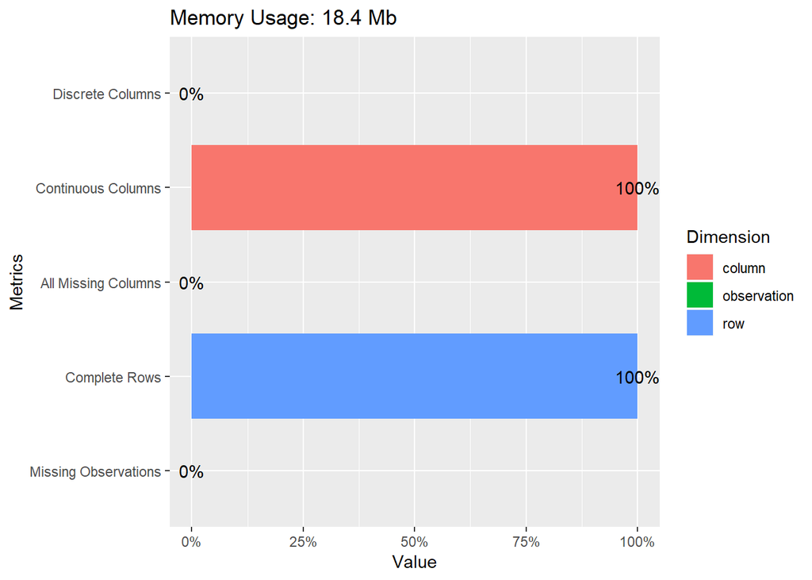

```r
# Cleaned data Statistics plot
plot_intro(supermarket_tbl_Clean1)
```

**Visualize the missing values in the cleaned dataset**

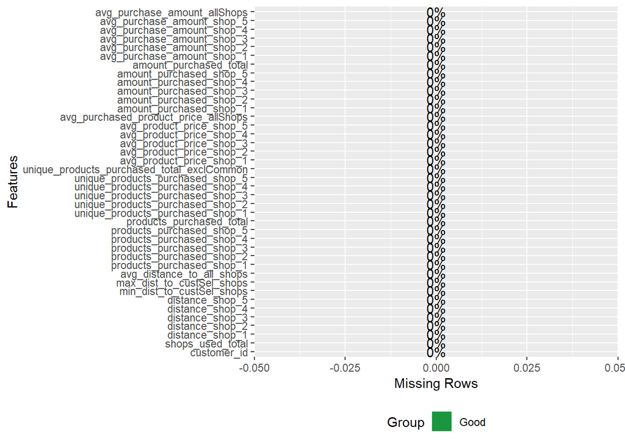

```r
## Plot missing values in the cleaned dataset after NA removal (Should have no missing values 0%)
plot_missing(supermarket_tbl_Clean1)
```

**Analyze the Continuous Variables in the cleaned dataset as a Histogram**

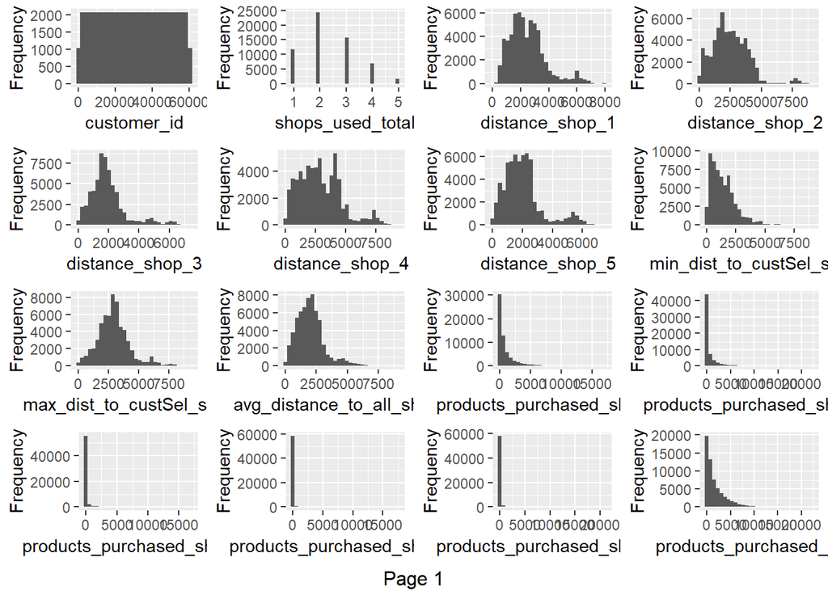

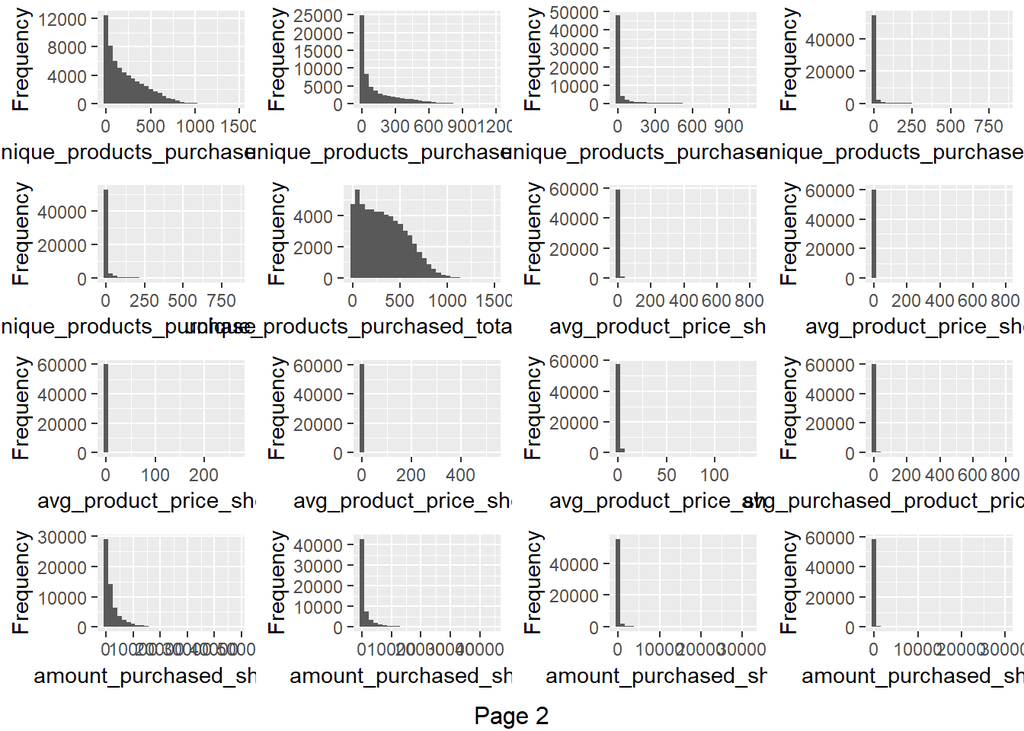

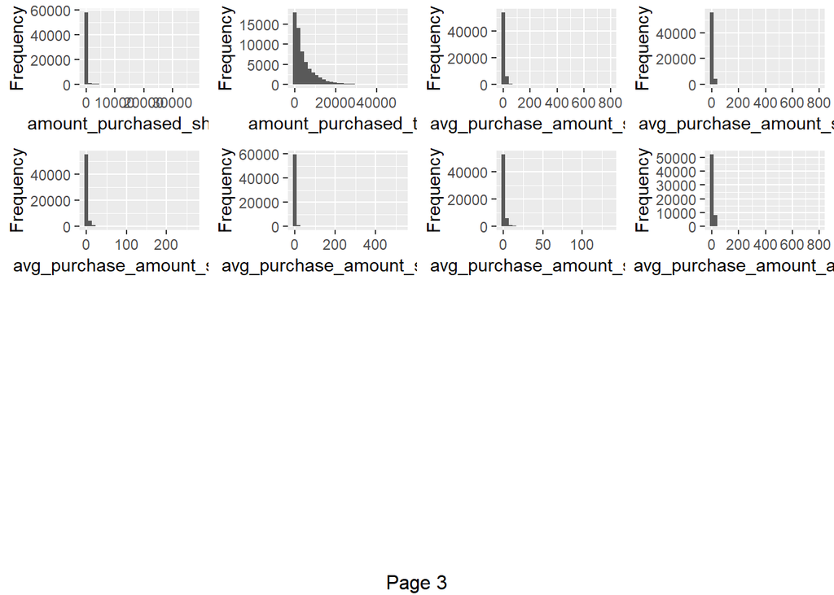

```r
# Analyze Continuous Variables in the cleaned dataset (Univariate Analysis)
plot_histogram(supermarket_tbl_Clean1)
```

**Examine the corelated features in the cleaned dataset through Correlation Analysis**

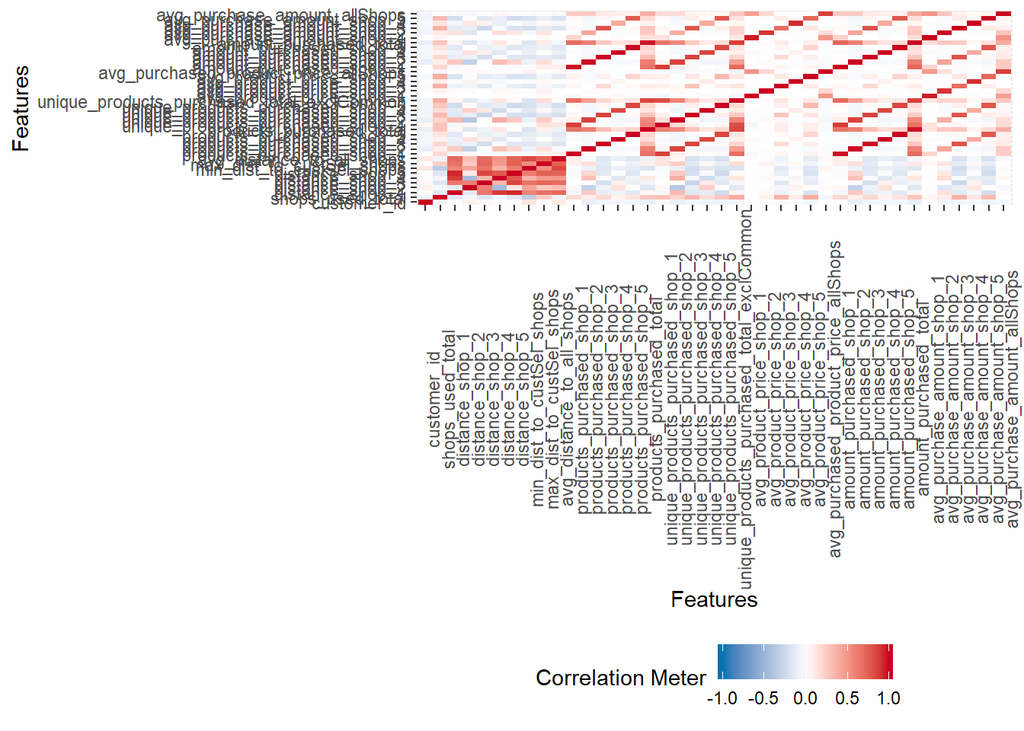

```r
# Correlation analysis (Multivariate Analysis, On Continuous features only) to examine corelated features in the cleaned dataset
plot_correlation(supermarket_tbl_Clean1, type = "c")
```

**Examine the variance-covariance structure and identify strong patterns in the cleaned dataset through Principal Component Analysis**

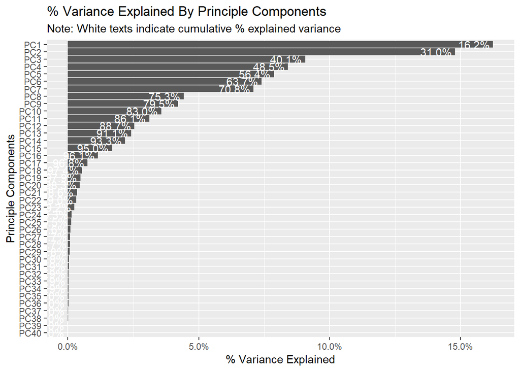

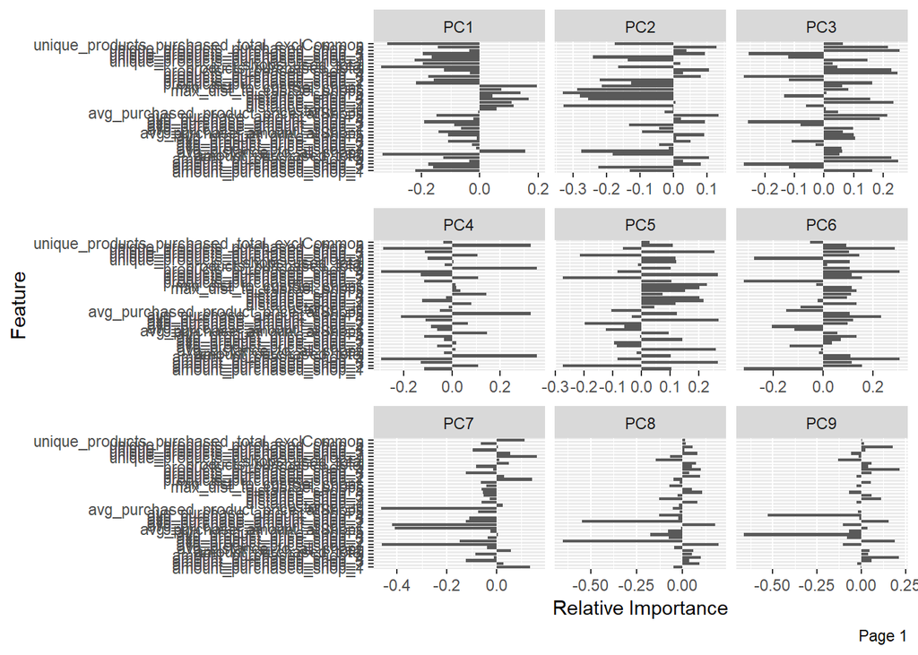

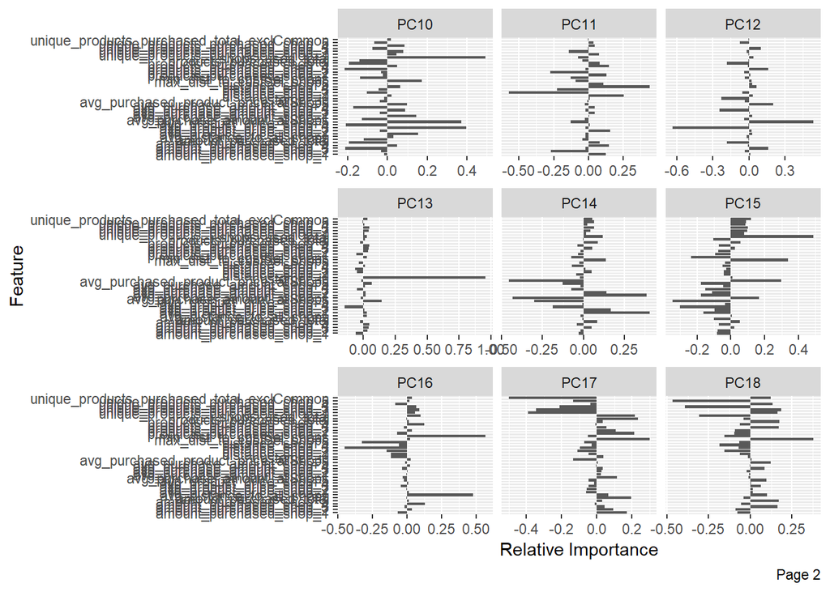

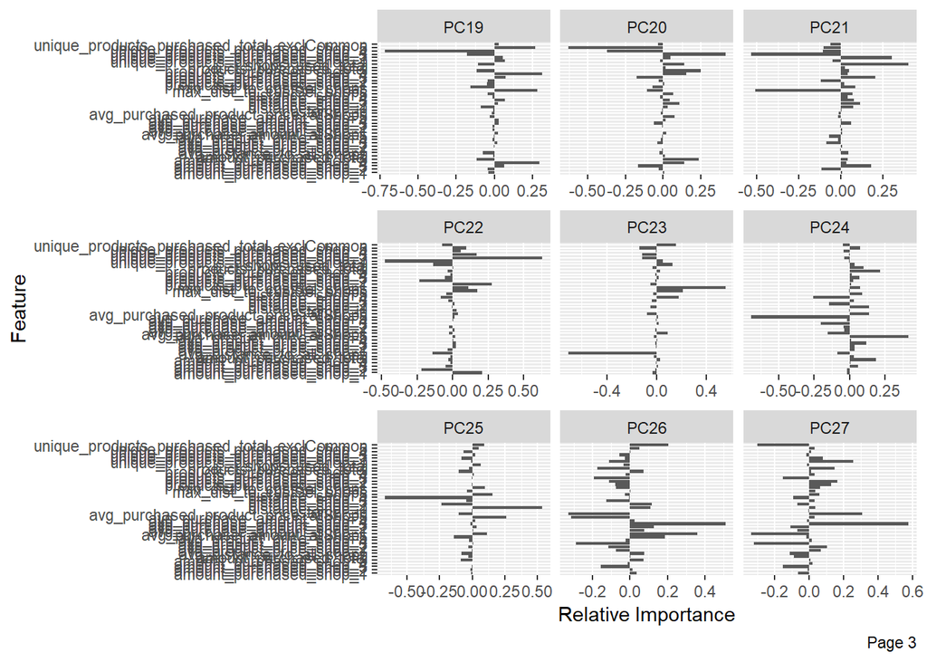

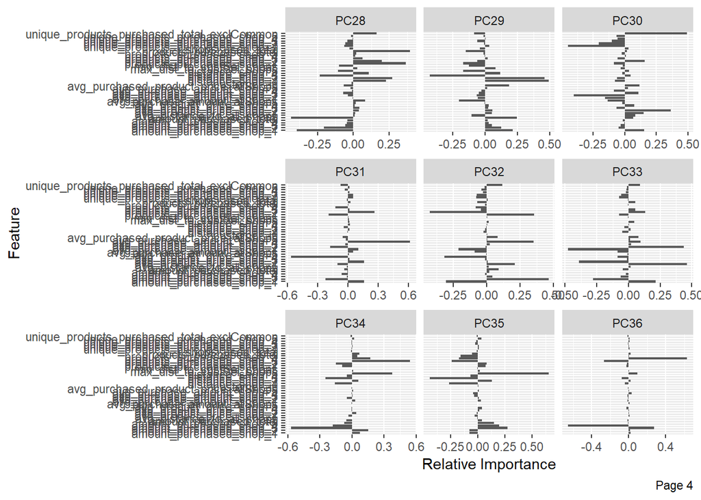

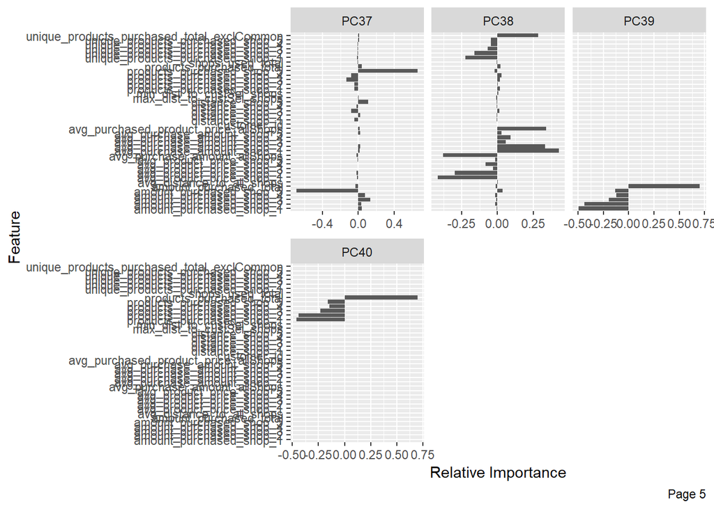

```r
# Principal Component Analysis to understand the variance-covariance structure and identify strong patterns in the cleaned dataset
plot_prcomp(supermarket_tbl_Clean1, variance_cap = 1)
```

**Visualize the deviation from a specific probability distribution in the cleaned dataset through Quantile-Quantile plot**

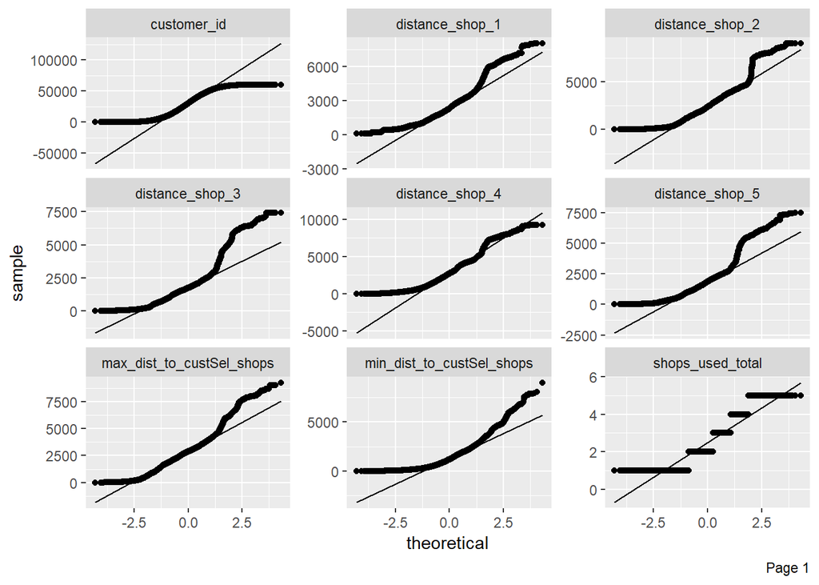

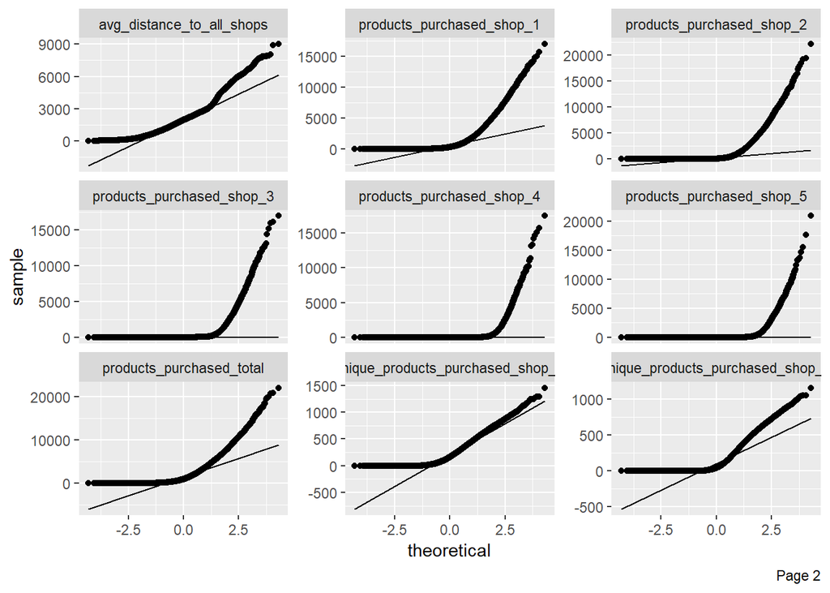

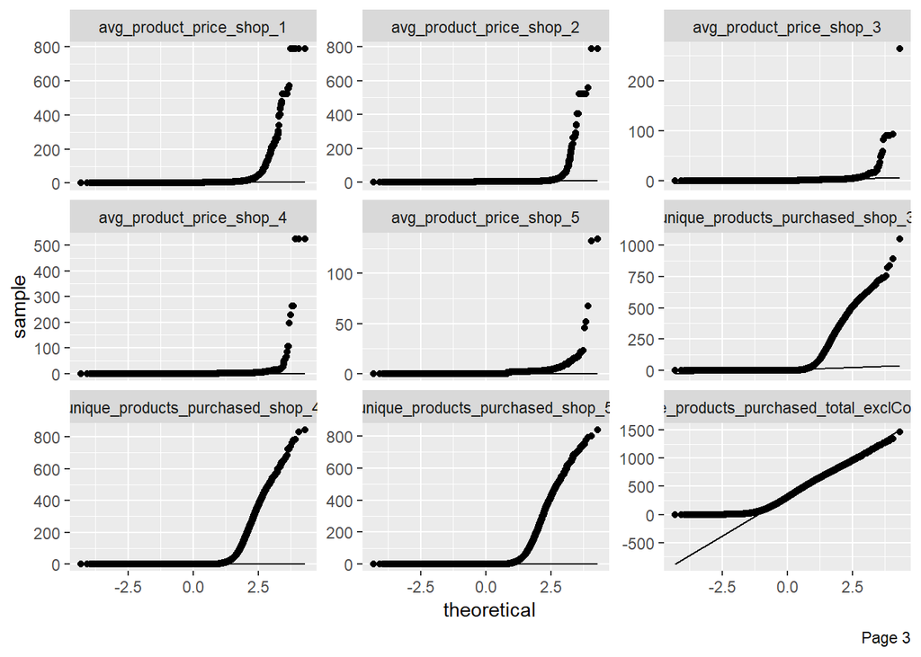

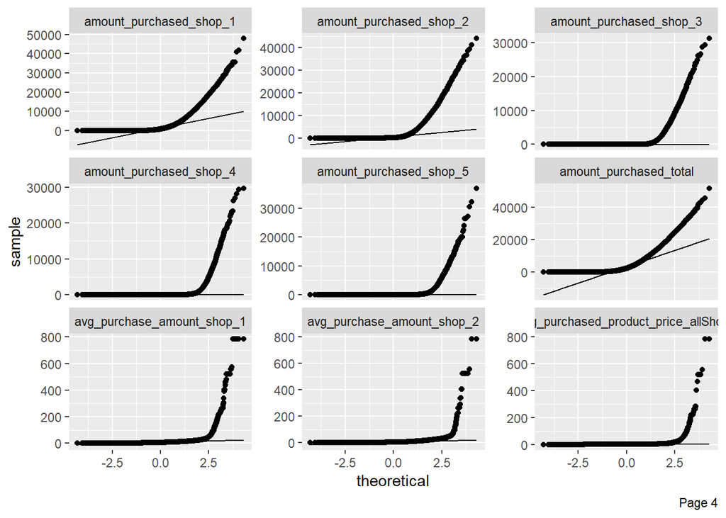

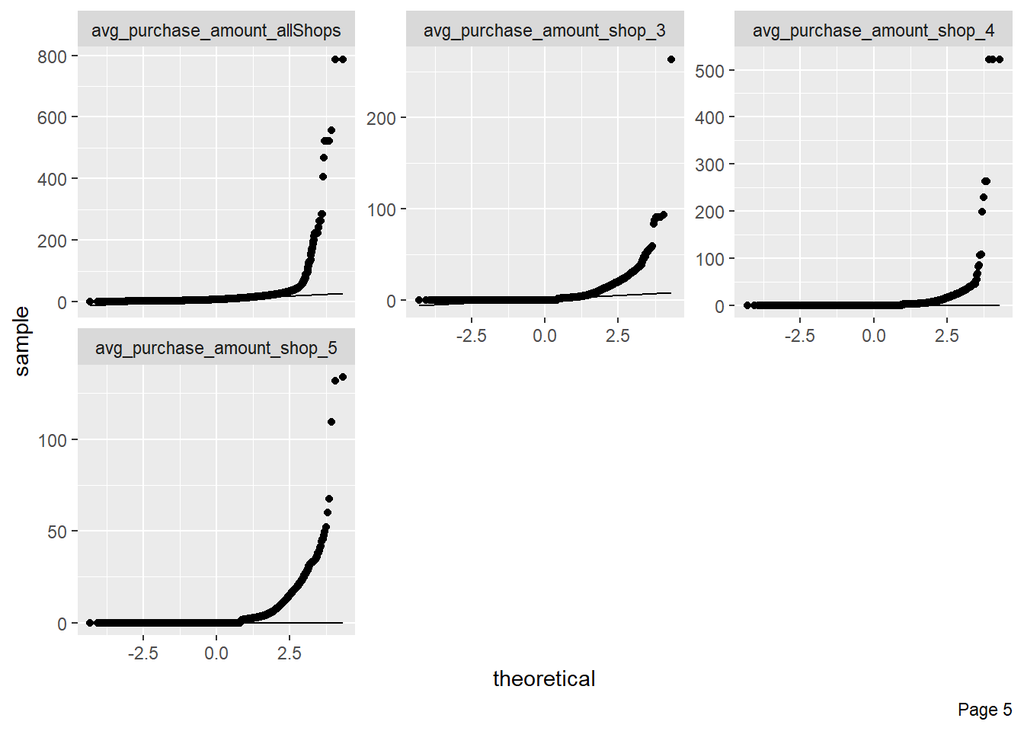

```r
# Quantile-Quantile plot to visualize the deviation from a specific probability distribution in the cleaned dataset
plot_qq(supermarket_tbl_Clean1)
```

#### **7. Exploratory Data Analysis**

Exploratory Data Analysis (EDA) is the process of visualizing the main characteristics in the data before the formal modeling on the data to discover data patterns and verify the initial primary assumptions made on the data. Below are the visualizations of the EDA carried out,

**1) Visualize the highest revenue generating shops, shops selling the highest number of products, shops selling the highest number of unique products and the relation between them**

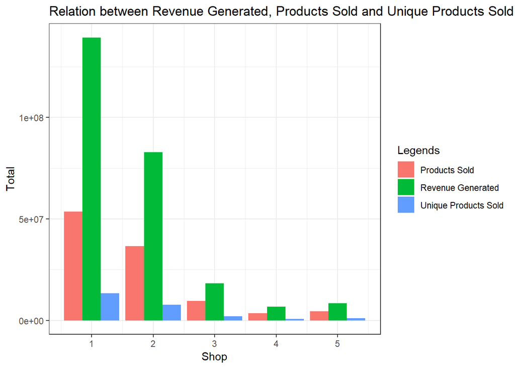

```r
library(ggplot2)
library("RColorBrewer")

file_path<- "Input Dataset/Cleaned Dataset/Supermarket_DataCleaned.csv"
supermarket_data_clean <- read_csv(file_path)

Shop<- c(1,2,3,4,5)

# Revenue generation by Shops 1-5
slice1<-select(supermarket_data_clean, 29,30,31,32,33)

amountS1<-sum(slice1$amount_purchased_shop_1)
amountS2<-sum(slice1$amount_purchased_shop_2)
amountS3<-sum(slice1$amount_purchased_shop_3)
amountS4<-sum(slice1$amount_purchased_shop_4)
amountS5<-sum(slice1$amount_purchased_shop_5)

# create data frame for Revenue generation
Revenue_Generated<- c(amountS1,amountS2,amountS3,amountS4,amountS5)
Revenue<- data.frame(Shop, Revenue_Generated)
rownames(Revenue) <- NULL

# Products Sold by Shops 1-5
slice2<-select(supermarket_data_clean, 11,12,13,14,15)

productsS1<-sum(slice2$products_purchased_shop_1)
productsS2<-sum(slice2$products_purchased_shop_2)
productsS3<-sum(slice2$products_purchased_shop_3)
productsS4<-sum(slice2$products_purchased_shop_4)
productsS5<-sum(slice2$products_purchased_shop_5)

# create data frame for Products Sold
Products_Purchased<- c(productsS1,productsS2,productsS3,productsS4,productsS5)
ProductsSold<- data.frame(Shop, Products_Purchased)
rownames(ProductsSold) <- NULL

# Unique products Sold by Shops 1-5
slice3<-select(supermarket_data_clean, 17,18,19,20,21)

uproductsS1<-sum(slice3$unique_products_purchased_shop_1)
uproductsS2<-sum(slice3$unique_products_purchased_shop_2)
uproductsS3<-sum(slice3$unique_products_purchased_shop_3)
uproductsS4<-sum(slice3$unique_products_purchased_shop_4)
uproductsS5<-sum(slice3$unique_products_purchased_shop_5)

# create data frame for Unique products Sold
UProducts_Purchased<- c(uproductsS1,uproductsS2,uproductsS3,uproductsS4,uproductsS5)
UProductsSold<- data.frame(Shop, UProducts_Purchased)
rownames(UProductsSold) <- NULL

# Plot a Bar graph to depict the above calculated data
Legends <-c(rep("Revenue Generated", 5), rep("Products Sold", 5), rep("Unique Products Sold", 5))
values <-c(Revenue_Generated, Products_Purchased, UProducts_Purchased)
mydata <-data.frame(Shop, values)

p <-ggplot(mydata, aes(Shop, values))
p +geom_bar(stat = "identity", aes(fill = Legends), position = "dodge") +
  xlab("Shop") + ylab("Total") +
  ggtitle("Relation between Revenue Generated, Products Sold and Unique Products Sold") +
  theme_bw()
```

*Analysis:* As visualized, the shops ordered based on the their highest Revenue Generated are Shop 1, 2, 3, 5, 4. The shops ordered based on the their highest amount of Products Sold are Shop 1, 2, 3, 5, 4. The shops ordered based on the their highest amount of Unique Products Sold are Shop 1, 2, 3, 4 & 5 (are on the same level). The relation between these parameters as visualized based on the shop order can be determined as the shop generating the highest revenue has the highest amount of products sold (unique included). So in the dataset, the relation between the revenue generated and the products sold is directly proportional to each other. The ordering of the shops is mostly stable here at Shop 1, 2, 3, 5, 4.

**2) Visualize the approximate customer base count for the different shops**

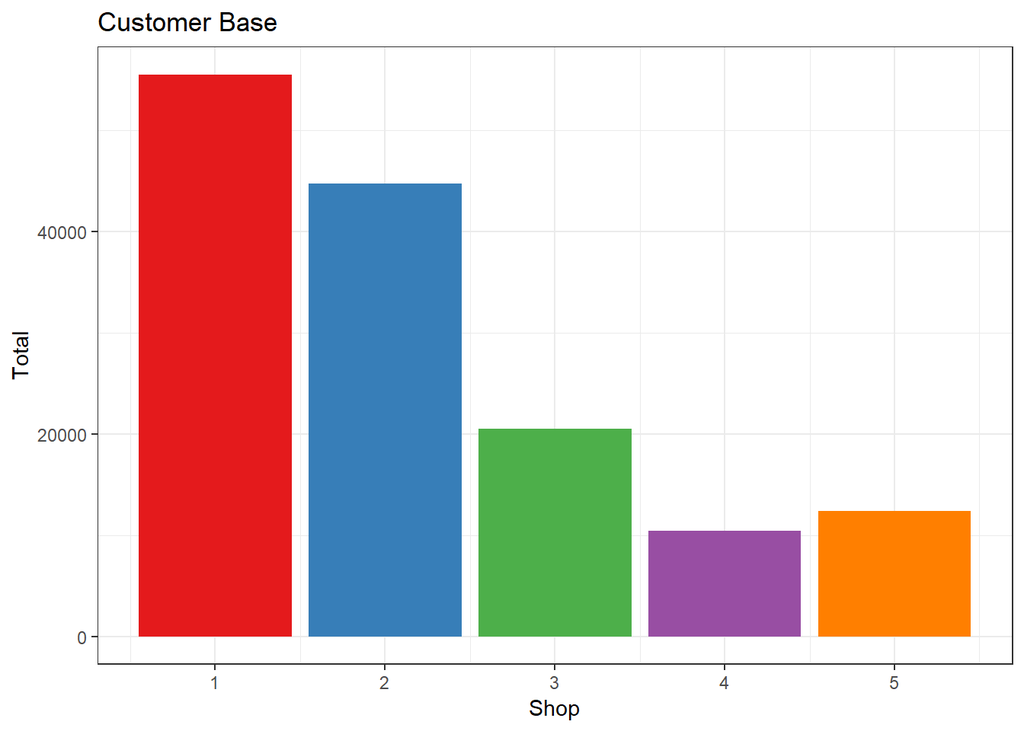

```r
# Approximate Customer Base for Shops 1-5

C1<-slice2$products_purchased_shop_1
custS1<-length(which(C1 !=0))

C2<-slice2$products_purchased_shop_2
custS2<-length(which(C2 !=0))

C3<-slice2$products_purchased_shop_3
custS3<-length(which(C3 !=0))

C4<-slice2$products_purchased_shop_4
custS4<-length(which(C4 !=0))

C5<-slice2$products_purchased_shop_5
custS5<-length(which(C5 !=0))

# create data frame for Approximate Customer Base
Customers<- c(custS1,custS2,custS3,custS4,custS5)
TotalCustomers<- data.frame(Shop, Customers)
rownames(TotalCustomers) <- NULL

# Plot a Bar graph to depict the approximate Customer Base
values <-c(Customers)
mydata <-data.frame(Shop, values)

p <-ggplot(mydata, aes(Shop, values))
p +geom_bar(stat = "identity", fill = brewer.pal(n = 5, name = "Set1"), position = "dodge") +
  xlab("Shop") + ylab("Total") +
  ggtitle("Customer Base") +
  theme_bw()
```

*Analysis:* As visualized, the shops ordered based on the their highest approximate customer base are Shop 1, 2, 3, 5, 4. So the highest approximate customer base for a shop determines its popularity in terms of a customer’s product purchase from the shop. The ordering of the shops is here as Shop 1, 2, 3, 5, 4.

**3) Visualize the relationship between average prices and distances to the shop**

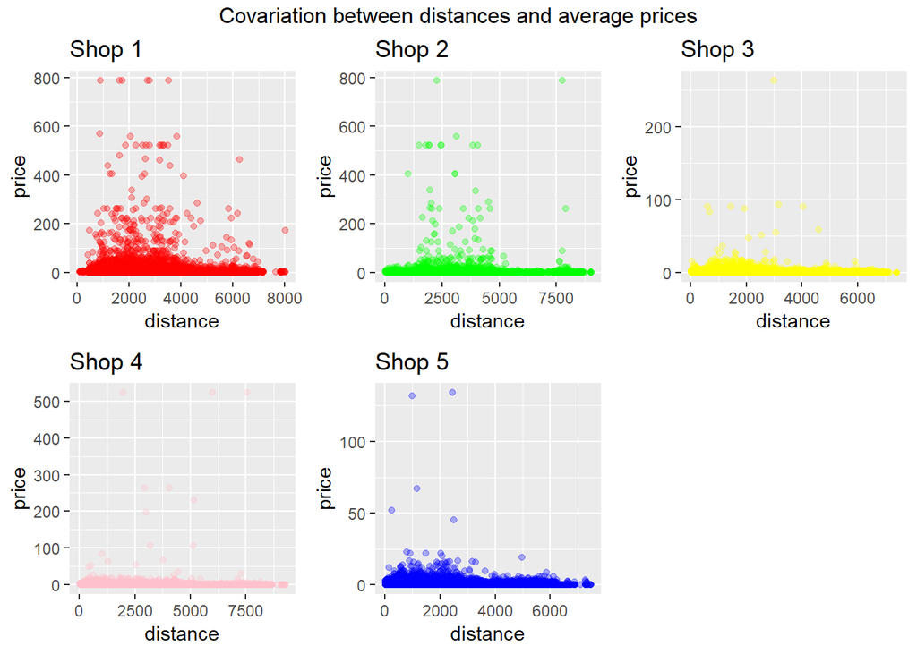

```r
library(modelr)
library(gridExtra)

cleared_supermarket_data<-read_csv(file_path)
cleared_supermarked_tbl <- tbl_df(cleared_supermarket_data)

shop_ordered_slice <- select(cleared_supermarked_tbl, 3,23,4,24,5,25,6,26,7,27) %>%
  bind_cols(cleared_supermarked_tbl[,8:10], cleared_supermarked_tbl[,28])

# Splitting the data
get_slice_for_shop <- function(col1, col2){
  shop_slice <- shop_ordered_slice[,col1:col2]
  colnames(shop_slice) <- c("distance","price")
  return(shop_slice)
}

shop_1_data <- get_slice_for_shop(1,2)
shop_2_data <- get_slice_for_shop(3,4)
shop_3_data <- get_slice_for_shop(5,6)
shop_4_data <- get_slice_for_shop(7,8)
shop_5_data <- get_slice_for_shop(9,10)
shop_avg_data <- get_slice_for_shop(13,14)
shop_agg_min_data <- get_slice_for_shop(11,14)
shop_agg_max_data <- get_slice_for_shop(12,14)

# Combine data to the one mutated table to show all shops at the one graph
joined_shops_data <- mutate(shop_1_data, Shop="1") %>%
  union_all(mutate(shop_2_data, Shop="2")) %>%
  union_all(mutate(shop_3_data, Shop="3")) %>%
  union_all(mutate(shop_4_data, Shop="4")) %>%
  union_all(mutate(shop_5_data, Shop="5"))

# Create base for plots
get_base_for_plot <- function(dataset, caption){
  plot_base <- ggplot(data = dataset, mapping = aes(x = distance, y = price)) + ggtitle(caption)
  return(plot_base)
}

# Colours list
colours_shema <- c("Red", "Green", "Yellow", "Pink", "Blue", "Purple", "steelblue1", "tomato1")

#create scatter plot
add_geom_point <- function(colorNum){
  geom_p <- geom_point(colour=colours_shema[colorNum], alpha=0.3)
  return(geom_p)
}

#draw scatter plot with plot base
draw_cov_point_plot <- function(dataset, colorNum, caption){
  cov_geom_plot <- get_base_for_plot(dataset, caption) + add_geom_point(colorNum)
  return(cov_geom_plot)
}

p1_1 <- draw_cov_point_plot(shop_1_data, 1, "Shop 1")
p2_1 <- draw_cov_point_plot(shop_2_data, 2, "Shop 2")
p3_1 <- draw_cov_point_plot(shop_3_data, 3, "Shop 3")
p4_1 <- draw_cov_point_plot(shop_4_data, 4, "Shop 4")
p5_1 <- draw_cov_point_plot(shop_5_data, 5, "Shop 5")
pavg_1 <- draw_cov_point_plot(shop_avg_data, 6, "Average price with average distance")
pmin_1 <- draw_cov_point_plot(shop_agg_min_data, 7, "Average price with min distance")
pmax_1 <- draw_cov_point_plot(shop_agg_max_data, 8, "Average price with max distance")

pall_1 <- get_base_for_plot(joined_shops_data, "All shops") + geom_point(mapping = aes(colour = Shop), alpha=0.3)

comb_cov_shops <- grid.arrange(p1_1, p2_1, p3_1, p4_1, p5_1,
                               nrow=2, ncol=3,
                               top="Covariation between distances and average prices")
```

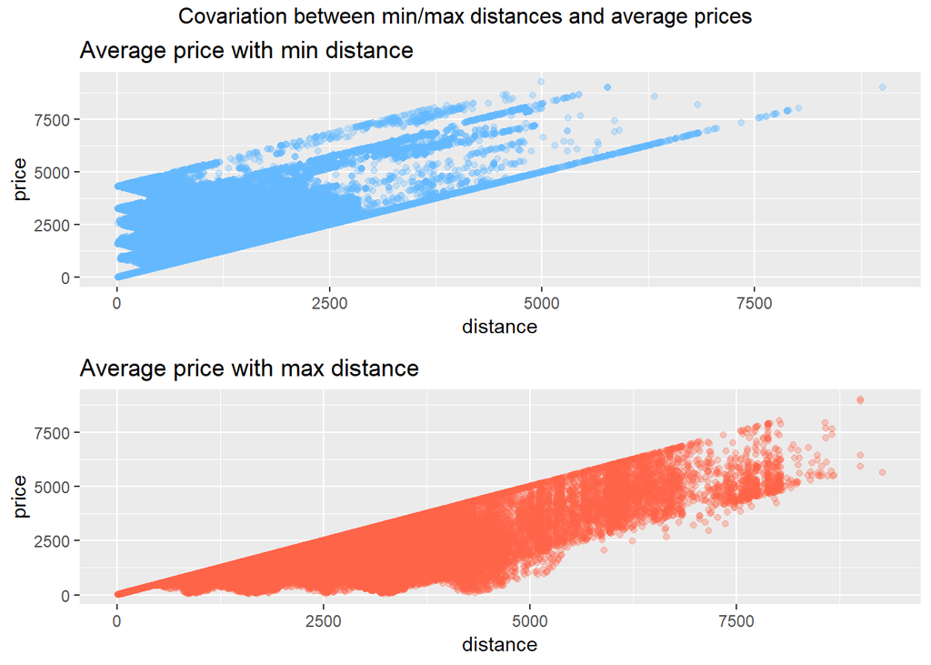

```r
comb_cov_aggrs <- grid.arrange(pmin_1, pmax_1,
                               nrow=2,
                               top= "Covariation between min/max distances and average prices")
```

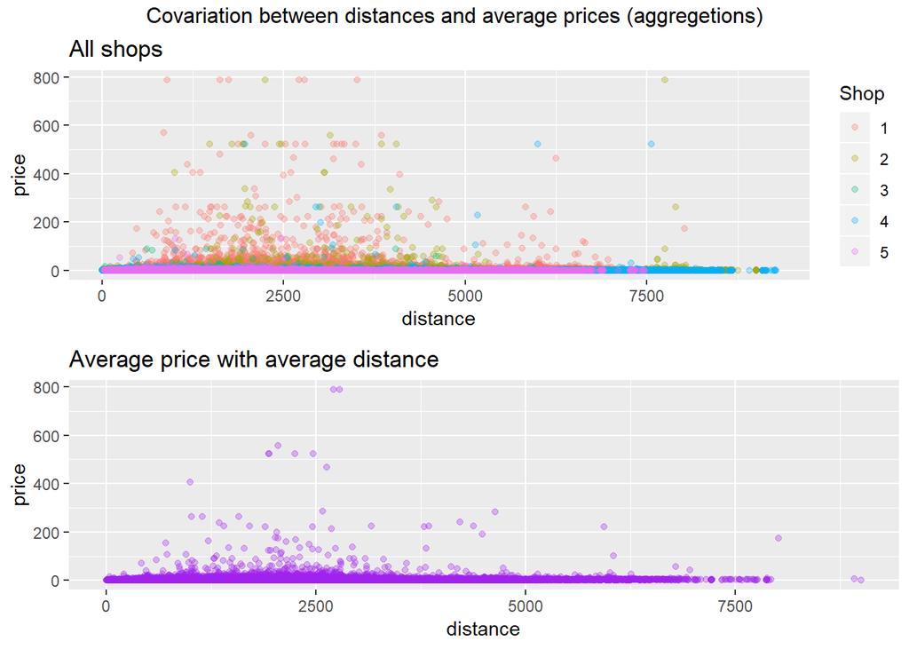

```r
comb_cov_avg <- grid.arrange(pall_1, pavg_1,
                               nrow=2,
                               top= "Covariation between distances and average prices (aggregetions)")
```

**4) Visualize data gap for average price in each shop**

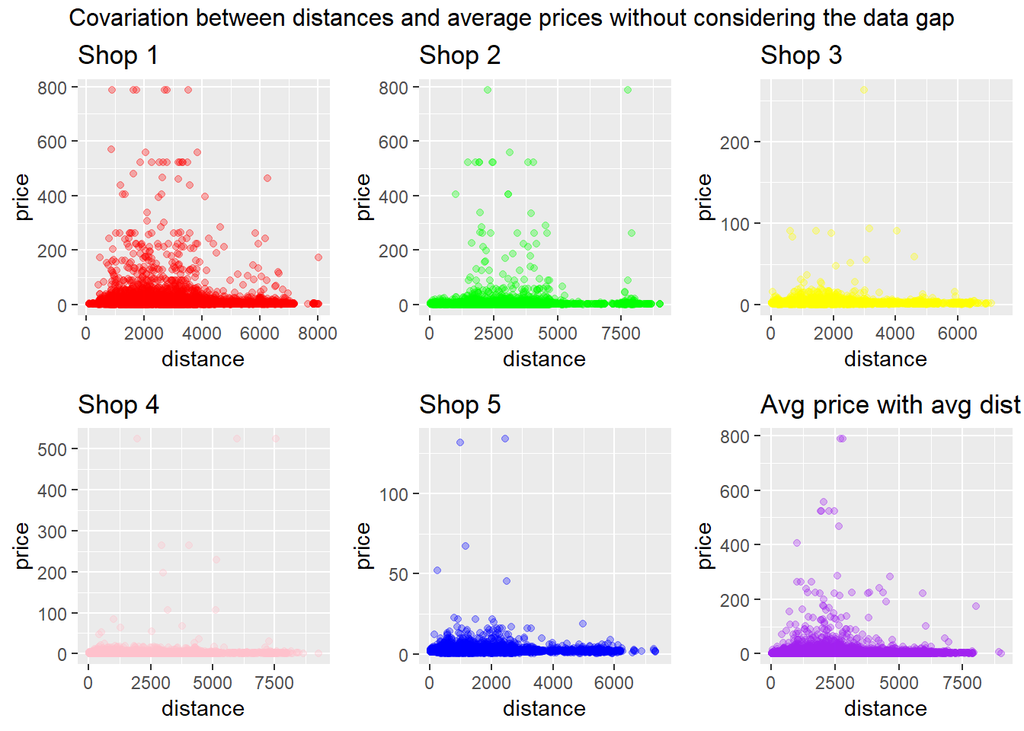

```r
draw_missing_values_plot  <- function(dataset, colorNum, caption){
  dataset_with_na <- dataset %>%
    mutate(price = ifelse(price == 0, NA, price))%>%
    mutate(missed = is.na(price))
  missing_values_plot <- get_base_for_plot(dataset_with_na, caption) +
    add_geom_point(colorNum)
  return(missing_values_plot)
}

p1_2 <- draw_missing_values_plot(shop_1_data, 1, "Shop 1")
p2_2 <- draw_missing_values_plot(shop_2_data, 2, "Shop 2")
p3_2 <- draw_missing_values_plot(shop_3_data, 3, "Shop 3")
p4_2 <- draw_missing_values_plot(shop_4_data, 4, "Shop 4")
p5_2 <- draw_missing_values_plot(shop_5_data, 5, "Shop 5")

pavg_2 <- draw_missing_values_plot(shop_avg_data, 6, "Avg price with avg dist")

comb_missing_vals <- grid.arrange(p1_2, p2_2, p3_2, p4_2, p5_2, pavg_2,
                               nrow=2, ncol=3,
                               top="Covariation between distances and average prices without considering the data gap")
```

*Analysis:* As visualized, there is a data gap for the value of average price in each shop. The value for average price in a shop for a customer is only filled in the dataset if the particular customer prefers the shop, else it is left as zero. This can be considered as a data gap but at the same time it is an information which is never utilized during analysis, meaning that the customer does not choose that particular shop in the first place. But this data gap does not affect on the tendency of the relationship between price and distance.

**5) Visualize the distribution density of the average price across shops**

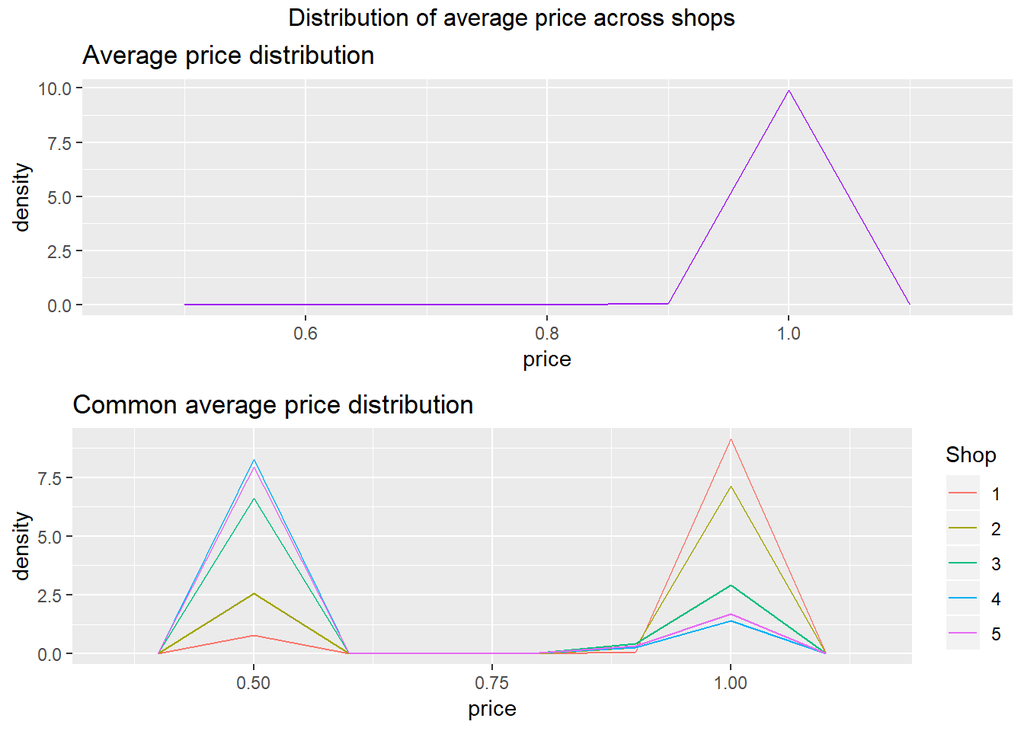

```r
# Normilizing of average price for common average data
dt_avg <- transform(shop_avg_data, price = pnorm(price))

pavg_3 <- ggplot(data = dt_avg, mapping = aes(x = price, y = ..density..)) +
  geom_freqpoly(colour=colours_shema[6], binwidth = 0.1) + ggtitle("Average price distribution")

# Normilizing of average price for shops
dt_all <- transform(joined_shops_data, price = pnorm(price))
pall_2 <- ggplot(data = dt_all, mapping = aes(x = price, y = ..density..)) +
  geom_freqpoly(mapping = aes(colour = Shop), binwidth = 0.1) + ggtitle("Common average price distribution")

comb_vis_distibution <- grid.arrange(pavg_3, pall_2,
                                     nrow=2, ncol=1,
                                     top="Distribution of average price across shops")
```

*Analysis:* As visualized, according to the data the average price is varyingly distributed in each shop.

**6) Visualize patterns for the average price**

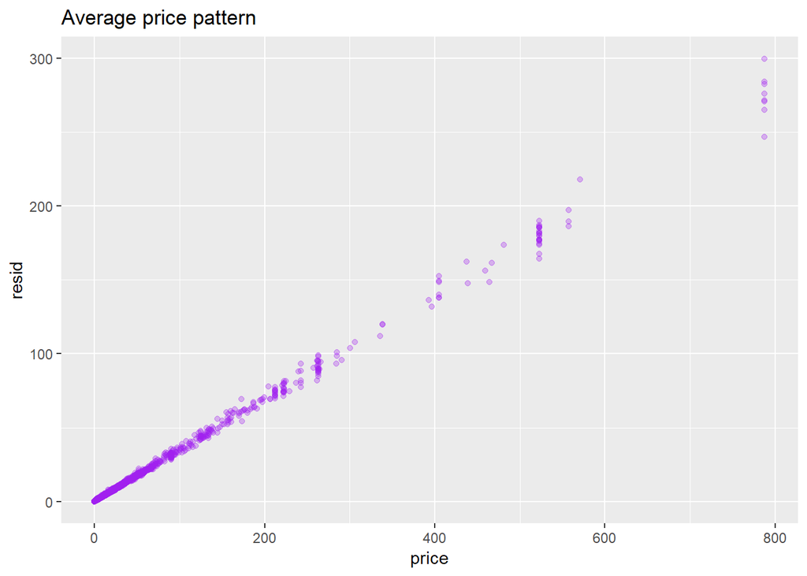

```r
joined_shops_without_null <- filter(joined_shops_data, price != 0)
mod <- lm(log(price) ~ log(distance), data = joined_shops_without_null)

joined_shops_data2 <- joined_shops_without_null %>%
  add_residuals(mod) %>%
  mutate(resid = exp(resid))


pall_3 <- ggplot(data = joined_shops_data2) +
  geom_point(mapping = aes(x = price, y = resid), colour=colours_shema[6], alpha=0.3) + ggtitle("Average price pattern")

pall_3
```

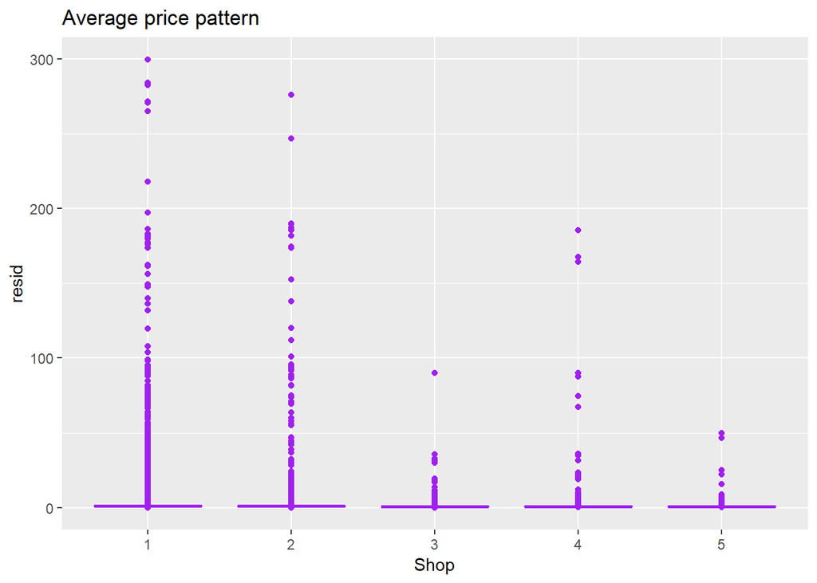

```r
pall_4 <- ggplot(data = joined_shops_data2) +
  geom_boxplot(mapping = aes(x = Shop, y = resid), color=colours_shema[6]) + ggtitle("Average price pattern")
pall_4
```

**7) Visualize the customer base for each shop based on different customer segments**

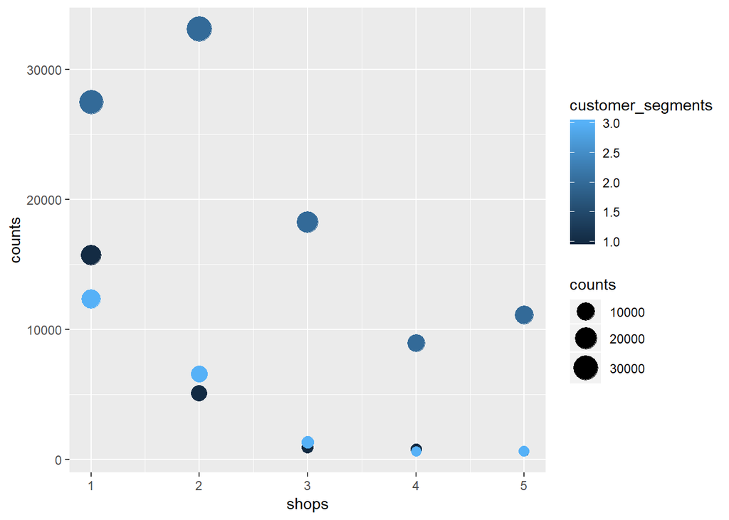

```r
## Ratio of products purchased from each shop (product purchased by a customer at a shop over total produccts purchased by that customer)
prod_purch_ratio_shop_1 <- with(supermarket_data_clean, products_purchased_shop_1/products_purchased_total)
prod_purch_ratio_shop_2 <- with(supermarket_data_clean, products_purchased_shop_2/products_purchased_total)
prod_purch_ratio_shop_3 <- with(supermarket_data_clean, products_purchased_shop_3/products_purchased_total)
prod_purch_ratio_shop_4 <- with(supermarket_data_clean, products_purchased_shop_4/products_purchased_total)
prod_purch_ratio_shop_5 <- with(supermarket_data_clean, products_purchased_shop_5/products_purchased_total)

## Ratio of amount spent at each shop (amount spent by a customer at a shop over total amount spent by that customer)
amt_purch_ratio_shop_1 <- with(supermarket_data_clean, amount_purchased_shop_1/amount_purchased_total)
amt_purch_ratio_shop_2 <- with(supermarket_data_clean, amount_purchased_shop_2/amount_purchased_total)
amt_purch_ratio_shop_3 <- with(supermarket_data_clean, amount_purchased_shop_3/amount_purchased_total)
amt_purch_ratio_shop_4 <- with(supermarket_data_clean, amount_purchased_shop_4/amount_purchased_total)
amt_purch_ratio_shop_5 <- with(supermarket_data_clean, amount_purchased_shop_5/amount_purchased_total)

## Loyality of customer to a shop (Ratio of products purchased from each shop times Ratio of amount spent at each shop)
loyality_shop_1 <- prod_purch_ratio_shop_1 * amt_purch_ratio_shop_1
loyality_shop_2 <- prod_purch_ratio_shop_2 * amt_purch_ratio_shop_2
loyality_shop_3 <- prod_purch_ratio_shop_3 * amt_purch_ratio_shop_3
loyality_shop_4 <- prod_purch_ratio_shop_4 * amt_purch_ratio_shop_4
loyality_shop_5 <- prod_purch_ratio_shop_5 * amt_purch_ratio_shop_5


## Data frames based on calculated values
prod_purch_ratio_shop <- data.frame(supermarket_data_clean$customer_id, prod_purch_ratio_shop_1, prod_purch_ratio_shop_2, prod_purch_ratio_shop_3, prod_purch_ratio_shop_4, prod_purch_ratio_shop_5)
amt_purch_ratio_shop <- data.frame(supermarket_data_clean$customer_id, amt_purch_ratio_shop_1, amt_purch_ratio_shop_2, amt_purch_ratio_shop_3, amt_purch_ratio_shop_4, amt_purch_ratio_shop_5)
loyality <- data.frame(supermarket_data_clean$customer_id, loyality_shop_1, loyality_shop_2, loyality_shop_3, loyality_shop_4, loyality_shop_5)

## Data frames as per shop nos
shop_1 <- data.frame(supermarket_data_clean$customer_id, prod_purch_ratio_shop_1, amt_purch_ratio_shop_1, loyality_shop_1)
shop_2 <- data.frame(supermarket_data_clean$customer_id, prod_purch_ratio_shop_2, amt_purch_ratio_shop_2, loyality_shop_2)
shop_3 <- data.frame(supermarket_data_clean$customer_id, prod_purch_ratio_shop_3, amt_purch_ratio_shop_3, loyality_shop_3)
shop_4 <- data.frame(supermarket_data_clean$customer_id, prod_purch_ratio_shop_4, amt_purch_ratio_shop_4, loyality_shop_4)
shop_5 <- data.frame(supermarket_data_clean$customer_id, prod_purch_ratio_shop_5, amt_purch_ratio_shop_5, loyality_shop_5)


## Customer segments for Shop 1 based on Loyality Score
high_end_shop_1 <- shop_1[which(shop_1$loyality_shop_1 > 0.9), ]
mid_range_shop_1 <- shop_1[which(shop_1$loyality_shop_1 > 0.50 & shop_1$loyality_shop_1 <= 0.9), ]
low_end_shop_1 <- shop_1[which(shop_1$loyality_shop_1 > 0 & shop_1$loyality_shop_1 <= 0.5), ]

## Customer segments for Shop 2 based on Loyality Score
high_end_shop_2 <- shop_2[which(shop_2$loyality_shop_2 > 0.9), ]
mid_range_shop_2 <- shop_2[which(shop_2$loyality_shop_2 > 0.50 & shop_2$loyality_shop_2 <= 0.9), ]
low_end_shop_2 <- shop_2[which(shop_2$loyality_shop_2 > 0 & shop_2$loyality_shop_2 <= 0.5), ]

## Customer segments for Shop 3 based on Loyality Score
high_end_shop_3 <- shop_3[which(shop_3$loyality_shop_3 > 0.9), ]
mid_range_shop_3 <- shop_3[which(shop_3$loyality_shop_3 > 0.50 & shop_3$loyality_shop_3 <= 0.9), ]
low_end_shop_3 <- shop_3[which(shop_3$loyality_shop_3 > 0 & shop_3$loyality_shop_3 <= 0.5), ]

## Customer segments for Shop 4 based on Loyality Score
high_end_shop_4 <- shop_4[which(shop_4$loyality_shop_4 > 0.9), ]
mid_range_shop_4 <- shop_4[which(shop_4$loyality_shop_4 > 0.50 & shop_4$loyality_shop_4 <= 0.9), ]
low_end_shop_4 <- shop_4[which(shop_4$loyality_shop_4 > 0 & shop_4$loyality_shop_4 <= 0.5), ]

## Customer segments for Shop 5 based on Loyality Score
high_end_shop_5 <- shop_5[which(shop_5$loyality_shop_5 > 0.9), ]
mid_range_shop_5 <- shop_5[which(shop_5$loyality_shop_5 > 0.50 & shop_5$loyality_shop_5 <= 0.9), ]
low_end_shop_5 <- shop_5[which(shop_5$loyality_shop_5 > 0 & shop_5$loyality_shop_5 <= 0.5), ]


## Number of customers in each segment for Shop 1
count_high_end_shop_1 <- nrow(high_end_shop_1)
count_mid_range_shop_1 <- nrow(mid_range_shop_1)
count_low_end_shop_1 <- nrow(low_end_shop_1)

## Number of customers in each segment for Shop 2
count_high_end_shop_2 <- nrow(high_end_shop_2)
count_mid_range_shop_2 <- nrow(mid_range_shop_2)
count_low_end_shop_2 <- nrow(low_end_shop_2)

## Number of customers in each segment for Shop 3
count_high_end_shop_3 <- nrow(high_end_shop_3)
count_mid_range_shop_3 <- nrow(mid_range_shop_3)
count_low_end_shop_3 <- nrow(low_end_shop_3)

## Number of customers in each segment for Shop 4
count_high_end_shop_4 <- nrow(high_end_shop_4)
count_mid_range_shop_4 <- nrow(mid_range_shop_4)
count_low_end_shop_4 <- nrow(low_end_shop_4)

## Number of customers in each segment for Shop 5
count_high_end_shop_5 <- nrow(high_end_shop_5)
count_mid_range_shop_5 <- nrow(mid_range_shop_5)
count_low_end_shop_5 <- nrow(low_end_shop_5)

## Setting up values
shops <- c(1, 1, 1, 2, 2, 2, 3, 3, 3, 4, 4, 4, 5, 5, 5)

customer_segments <- c("high", "med", "low", "high", "med", "low", "high", "med", "low", "high", "med", "low", "high", "med", "low")

count_shop_1 <- c(count_high_end_shop_1, count_mid_range_shop_1, count_low_end_shop_1)
count_shop_2 <- c(count_high_end_shop_2, count_mid_range_shop_2, count_low_end_shop_2)
count_shop_3 <- c(count_high_end_shop_3, count_mid_range_shop_3, count_low_end_shop_3)
count_shop_4 <- c(count_high_end_shop_4, count_mid_range_shop_4, count_low_end_shop_4)
count_shop_5 <- c(count_high_end_shop_5, count_mid_range_shop_5, count_low_end_shop_5)

counts <- c(count_shop_1, count_shop_2, count_shop_3, count_shop_4, count_shop_5)


## Count of customers based on the three customer segments (high, mid, low)
shop_customer_segment_count <-data.frame(shops, customer_segments, counts)

## Change datatype of columns to numerical
shop_customer_segment_count <- shop_customer_segment_count %>% mutate_if(is.integer, as.numeric) %>% mutate_if(is.factor, as.numeric)

## Plot the count of customers for each shop based on customer segments (high - 1, mid - 3, low - 2)
qplot(shops, counts, data = shop_customer_segment_count, size=counts, color = customer_segments) +
    scale_size_continuous(range = c(3, 8))
```

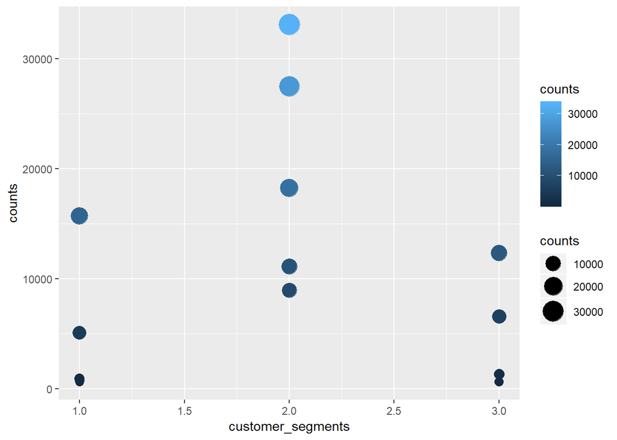

```r
## Plot the count of customers for each segment
qplot(customer_segments, counts, data = shop_customer_segment_count, size=counts, color = counts) +
    scale_size_continuous(range = c(3, 8))
```

**Analysis:** As visualized, the customers can be categorized on the basis of three different customer segements i.e. high, mid and low in terms of their loyality towards the shops and promotional offers can be customised for each segment.

#### **8. Final Research Questions**

Exploratory Data Analysis provided a feasibility check on the Initial RQs formulated. The EDA phase helped to get a better understanding of the data in relation with the project objective. Hence this lead to the modification, removal or addition of new RQ. Below is the final set of RQ formulated which will be answered through this project,

**1. Are customers willing to travel long distances to purchase products in spite of the high average product price in a shop?**  
*Relevance:* This will help to understand whether the price is an important factor affecting the majority of customers purchase decisions.

**2. What are the factors that contribute towards the long distance travel of the customer to purchase products in spite of the high average product price in a shop?**  
*Relevance:* This will help to understand the important factors that contribute towards the customers willing to travel long-distances to purchase products in spite of the high average product price in a shop, in turn better understanding the purchase behaviour of the customers

**3. What is the maximum likelihood of a customer to select a particular shop?**  
*Relevance:* This will help to understand that which shops in the retail chain are in demand and predict their estimated customer base. This can further facilitate better stock management to meet customer demands.

**4. What are the different customer segments based on their purchase behaviour?**  
*Relevance:* This will help to understand the groups of similar customer based on their purchase behviour and target different shop-level marketing schemes to the appropriate customers.

**5. Which are the Top 100 customers that are most profitable in terms of revenue generation?**  
*Relevance:* This will help to understand the customers with potential high Customer Lifetime Value and target appropriate loyalty programs to generate satisfied loyal customers as advocates for the business.

#### **9. Final Analysis**

**1. Are customers willing to travel long distances to purchase products in spite of the high average product price in a shop?**

**2. What are the factors that contribute towards the long distance travel of the customer to purchase products in spite of the high average product price in a shop?**

**3. What is the maximum likelihood of a customer to select a particular shop?**

**4. What are the different customer segments based on their purchase behaviour?**

**5. Which are the Top 100 customers that are most profitable in terms of revenue generation?**

#### **10. Important Links**

**1. GitHub Repository** https://github.com/Rspawar/Data-Science-with-R.git

**5. Complete Analysis Report as RMarkdown file** https://github.com/Rspawar/Data-Science-with-R/blob/master/Customer%20Behavioural%20Analytics%20in%20the%20Retail%20sector.Rmd

**6. complete Analysis Report as HTML file** https://github.com/Rspawar/Data-Science-with-R/blob/master/Customer_Behavioural_Analytics_in_the_Retail_sector.html

#### **Date**

`December 7, 2018`

#### **References**

Pennacchioli, Diego, Michele Coscia, Salvatore Rinzivillo, Dino Pedreschi, and Fosca Giannotti. 2013. “Explaining the Product Range Effect in Purchase Data.” In *Big Data, 2013 Ieee International Conference on*, 648–56. IEEE.

[^1]: https://bigml.com/user/czuriaga/gallery/dataset/5559c2c6200d5a6570000084
[^2]: http://www.michelecoscia.com/?page_id=379